# Collecting Twitter Data through Academic API

## Building Queries

### Manual Queries

Twitter Academic API can accept fairly complex queries (a query can be 1024 characters long!). This [link](https://developer.twitter.com/en/docs/twitter-api/tweets/search/integrate/build-a-query) provides a detailed overview of building queries with some examples.

Suppose that we are interested in tweets containing the hashtag *#BlackLivesMatter* from a specific country, United States, that are only English. We also want to exclude retweets. For collecting tweets by country, we can use the `place_country` operator.

```r
blm_query1 <- get_all_tweets("#BlackLivesMatter place_country:US lang:en -is:retweet",
                             start_tweets = "2020-01-01T00:00:00Z",
                             end_tweets = "2020-03-01T00:00:00Z",
                             bearer_token
                             )
```

```
## query: <#BlackLivesMatter place_country:US lang:en -is:retweet>: (tweets captured this page: 497). Total pages queried: 1. Total tweets ingested: 497.
## query: <#BlackLivesMatter place_country:US lang:en -is:retweet>: (tweets captured this page: 424). Total pages queried: 2. Total tweets ingested: 921.
## This is the last page for #BlackLivesMatter place_country:US lang:en -is:retweet : finishing collection.
```

Now, our columns related to geographical metadata is not empty anymore. But, unfortunately, we are now getting way less tweets than we would have without the location.

```r
head(blm_query1$geo)
```

```
##           place_id coordinates.type coordinates.coordinates
## 1 01a9a39529b27f36            Point     -73.96244, 40.78061
## 2 01a9a39529b27f36            Point     -73.96244, 40.78061
## 3 c47c0bc571bf5427             <NA>                    NULL
## 4 9b101e0451f073b6             <NA>                    NULL
## 5 9b101e0451f073b6             <NA>                    NULL
## 6 01a9a39529b27f36            Point     -74.00433, 40.70665
```

This is how our previous queries without geographical metadata looks like

```r
head(tweets1$geo)
```

```
##   place_id coordinates.type coordinates.coordinates
## 1     <NA>             <NA>                    NULL
## 2     <NA>             <NA>                    NULL
## 3     <NA>             <NA>                    NULL
## 4     <NA>             <NA>                    NULL
## 5     <NA>             <NA>                    NULL
## 6     <NA>             <NA>                    NULL
```

We can collect tweets from a specific place using the `place` operator. Let’s say we want to collect tweets in English from California.

```r
## What if we are interested in a specific location? Say, California
blm_query2 <- get_all_tweets("#BlackLivesMatter place:California lang:en -is:retweet",
                             start_tweets = "2020-01-01T00:00:00Z",
                             end_tweets = "2020-03-01T00:00:00Z",
                             bearer_token
)
```

```
## query: <#BlackLivesMatter place:California lang:en -is:retweet>: (tweets captured this page: 9). Total pages queried: 1. Total tweets ingested: 9.
## This is the last page for #BlackLivesMatter place:California lang:en -is:retweet : finishing collection.
```

```r
## here, we need to investigate this further before we rely on this query, e.g. we might represent the same place with different names, e.g. CA etc. (gives 199 tweets!)..We can make more complex queries to avoid
# this ambiguity. See tweets with exact location
## https://developer.twitter.com/en/docs/twitter-api/v1/data-dictionary/object-model/geo
```

We can also use an operator called `bounding box`. This allows to specify a 4-sided geographic area and match Tweets containing Tweet-specific location data that fall within that area. Let’s say we are interested in collecting tweets with the hastag *#BlackLivesMatter* in the Bronx area.

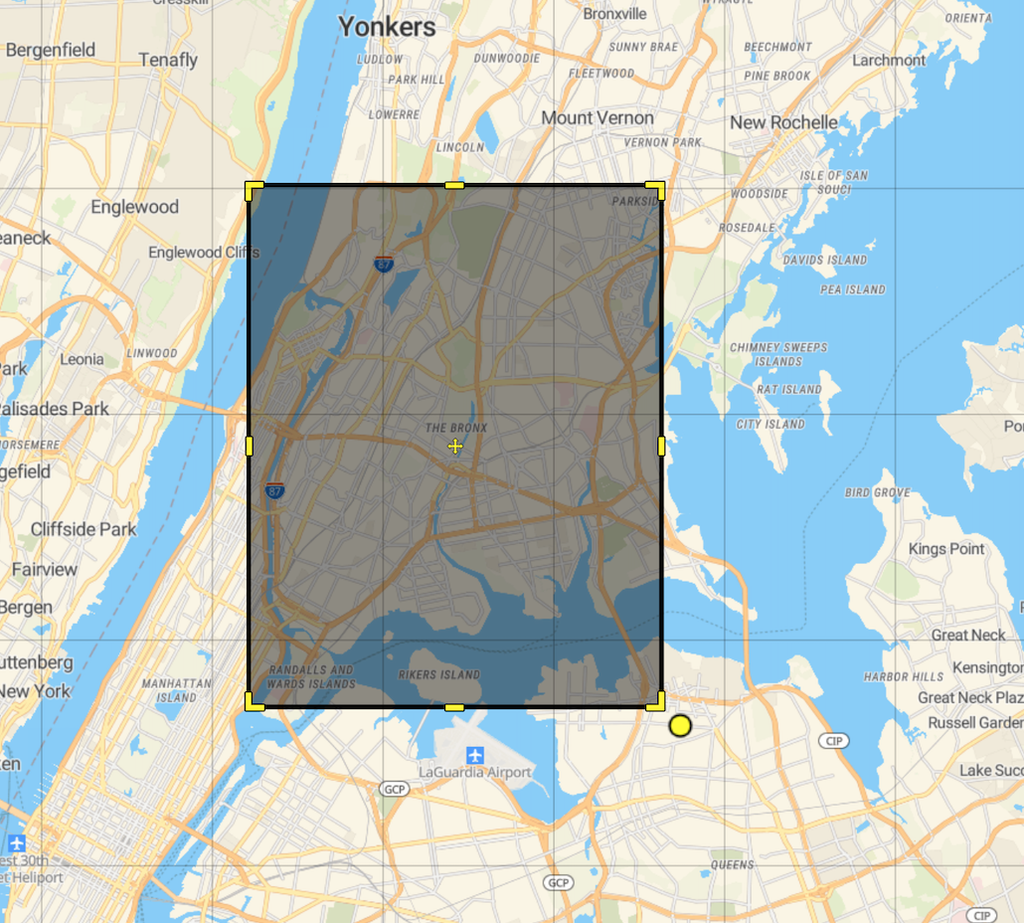

Bronx, Bounding Box

```r
## bounding_box:[west_long south_lat east_long north_lat]
# -73.9393484455,40.785171272,-73.8185225894,40.9007276281
## each side of the box is up to 25 miles in length.
blm_query3 <- get_all_tweets("#BlackLivesMatter bounding_box:[-73.93 40.78 -73.82 40.90] lang:en",
                             start_tweets = "2020-01-01T00:00:00Z",
                             end_tweets = "2020-4-01T00:00:00Z",
                             bearer_token)
```

```
## query: <#BlackLivesMatter bounding_box:[-73.93 40.78 -73.82 40.90] lang:en>: (tweets captured this page: 1). Total pages queried: 1. Total tweets ingested: 1.
## query: <#BlackLivesMatter bounding_box:[-73.93 40.78 -73.82 40.90] lang:en>: (tweets captured this page: 16). Total pages queried: 2. Total tweets ingested: 17.
## This is the last page for #BlackLivesMatter bounding_box:[-73.93 40.78 -73.82 40.90] lang:en : finishing collection.
```

Another operator for collecting tweets by location is the `point_radius` operator. This allows to specify a circular geographic area and match Tweets containing Tweet-specific location data that fall within that area. For example, we can look at the tweets containing the keyword *insurrection* in a 25 miles radius around the Capitol on January 6, 2021.

[figure not shown]

Capitol, Radius

```r
## point_radius:[lon lat radius]
## radius must be less than 25 miles!
capitol_radius <- get_all_tweets("insurrection point_radius:[-77.009017 38.890550 25mi]",
                                 start_tweets = "2021-01-05T00:00:00Z",
                                 end_tweets = "2021-01-07T00:00:00Z",
                                 bearer_token)
```

```
## query: <insurrection point_radius:[-77.009017 38.890550 25mi]>: (tweets captured this page: 141). Total pages queried: 1. Total tweets ingested: 141.
## This is the last page for insurrection point_radius:[-77.009017 38.890550 25mi] : finishing collection.
```

```r
## take a peek at geo info
head(capitol_radius$geo)
```

```
##           place_id coordinates.type coordinates.coordinates
## 1 01fbe706f872cb32             <NA>                    NULL
## 2 7c6c97d9031b9d8a             <NA>                    NULL
## 3 01fbe706f872cb32             <NA>                    NULL
## 4 01fbe706f872cb32             <NA>                    NULL
## 5 d6819fe60643ebc1             <NA>                    NULL
## 6 01fbe706f872cb32             <NA>                    NULL
```

### Query Builder

Manual approach requires to know the syntax of Twitter API queries. Alternatively, we can benefit from the academictwitteR package’s own query builder, `build_query` function.

We can build tweet queries according to the following parameters.

```r
args(build_query)
```

```
## function (query, exclude = NULL, is_retweet = NULL, is_reply = FALSE,
##     is_quote = FALSE, is_verified = FALSE, place = NULL, country = NULL,
##     point_radius = NULL, bbox = NULL, geo_query = FALSE, remove_promoted = FALSE,
##     has_hashtags = FALSE, has_cashtags = FALSE, has_links = FALSE,
##     has_mentions = FALSE, has_media = FALSE, has_images = FALSE,
##     has_videos = FALSE, has_geo = FALSE, lang = NULL)
## NULL
```

The example below shows how to build a query to collect tweets containing the *#BlackLivesMatter* hashtag by country. This function will build us a tweet query. We will then use this as an input in the function `get_all_tweets` as query parameter.

```r
blm_querybuild <- build_query(query = "#BlackLivesMatter", country = "US", lang = "en")
blm_querybuild
```

```
## [1] "#BlackLivesMatter place_country:US lang:en"
```

```r
blmquery_tweets <- get_all_tweets(blm_querybuild, # insert query parameter from the build quey function
                             start_tweets = "2020-01-01T00:00:00Z",
                             end_tweets = "2020-03-01T00:00:00Z",
                             bearer_token
                             )
```

```
## query: <#BlackLivesMatter place_country:US lang:en>: (tweets captured this page: 497). Total pages queried: 1. Total tweets ingested: 497.
## query: <#BlackLivesMatter place_country:US lang:en>: (tweets captured this page: 424). Total pages queried: 2. Total tweets ingested: 921.
## This is the last page for #BlackLivesMatter place_country:US lang:en : finishing collection.
```

## Interruption and Continuation

When making long API calls, there might be some interruptions. `resume_collection` function resumes a previous interrupted collection session. Because we don’t experienced any interruption while collecting immigration tweets, the function won’t give us any new tweets.

```r
resume_collection(data_path = "immigration_tweets", bearer_token)
```

```
## ================================================================================
## Query: "sanctuary city" OR #sanctuarycity
## Start date: 2018-01-01T00:00:00Z
##  End date: 2018-01-01T00:02:29.000Z
## query: <"sanctuary city" OR #sanctuarycity>: (tweets captured this page: ). Total pages queried: 1. Total tweets ingested: .
## This is the last page for "sanctuary city" OR #sanctuarycity : finishing collection.
```

```
## data frame with 0 columns and 0 rows
```

We can also use the `update_collection` function if we want to continue previous collection session with a new end date.

```r
#update_collection(data_path = "governors_tweets", end_tweets = "2021-06-10T00:00:00Z",
 #                bearer_token)
```

## Some Useful Links

- Here are some other useful functions from the academictwitteR package you might want to explore:
  - `get_country_tweets`: collects tweets containing specific keywords and hashtags between specified date ranges filtering by country.
  - `get_geo_tweets`: collects tweets containing specific keywords and hashtags between specified date ranges that also contain Tweet-specific geolocation data provided by the Twitter user.
  - `get_lang_tweets`: collects tweets containing specific keywords and hashtags between specified date ranges by language.
  - `get_mention_tweets`: collects tweets containing specific keywords and hashtags between specified date ranges that also contain mentions of other Twitter users.
- Here are links to some demos by the creators of the package, Christopher Barrie and Justin Chun-ting Ho.
  - academicTwitteR Demo by Christopher Barrie and Justin Chun-ting Ho [Link](https://raw.githack.com/cjbarrie/twitter_twitch/main/demo.html)
  - academicTwitteR Github page [Link](https://github.com/cjbarrie/academictwitteR)
- Here are some sources on Twitter Academic API by Twitter
  - Tutorials, articles, and code samples of using academic API by Twitter [Link](https://developer.twitter.com/en/use-cases/do-research/academic-research/resources#infrastructure-hostingsolutions.)
  - Data Dictionary/Returned Objects [Link](https://developer.twitter.com/en/docs/twitter-api/data-dictionary/object-model/tweet)
  - Building Queries [Link](https://developer.twitter.com/en/docs/twitter-api/tweets/search/integrate/build-a-query)
  - Twitter Developer’s Forum Discussion for Academic Research [Link](https://twittercommunity.com/c/academic-research/62)

If you have any questions, please free to reach out! My email is bk457@polisci.rutgers.edu